# Frequently Asked Questions

# Frequently Asked Questions

## The X axis should be “1-Specificity” instead of “Specificity”!

This is not a bug!

Most statistical tools cannot plot specificity from 1 to 0, so instead they plot 1-specificity from 0 to 1. This results in exactly the same plot, just with a different labelling of the axis.

R doesn’t have this limitation, and `pROC` plots specificity from 1 to 0, saving you from doing a few subtractions when you look at the plot.

If you are concerned that your reviewers will be confused and really wish to have the “old-style” 1-Specificity from 0 to 1, or if you plan to change the axis label to “False Positive Rate” (which is really 1-specificity), you can use the `legacy.axes` argument to the plot function. See `?plot.roc` for more details.

Here is a comparison of the two plotting styles:

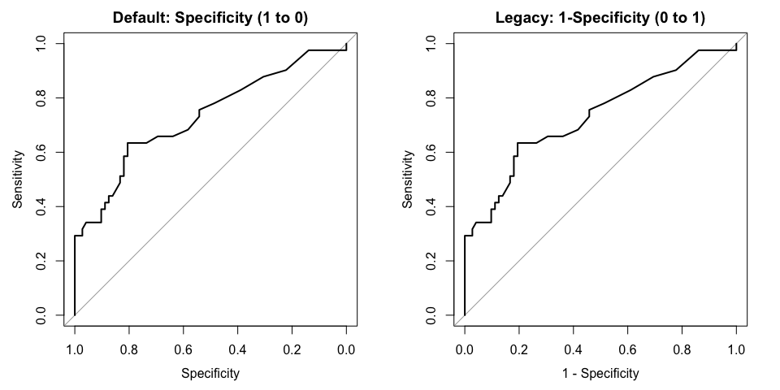

```r
library(pROC)
data(aSAH)

# Create a ROC curve
rocobj <- roc(aSAH$outcome, aSAH$s100b)

# Plot with default axis (Specificity from 1 to 0)
par(mfrow = c(1, 2))
plot(rocobj, main = "Default: Specificity (1 to 0)")

# Plot with legacy axis (1-Specificity from 0 to 1)
plot(rocobj, main = "Legacy: 1-Specificity (0 to 1)",
     legacy.axes = TRUE)
```

```r
par(mfrow = c(1, 1))
```

## I have a GLM/SVM/PLS/ model, how can I analyze it with pROC?

You need to use the `predict()` function to get predictions that can be passed to pROC (as the `predictor` argument).

Specifically you need to get a single vector of numeric predictions. In some cases you may have to add pass `type="probabilities"` or something similar to the `predict` function (to get probabilities instead of the binary response), sometimes you may to have select one of the column of the returned matrix (if `predict` returns a matrix of class probabilities). Read the documentation of the package you’re using and look at your results to find out what to do exactly.

Here is a concrete example using `glm()`:

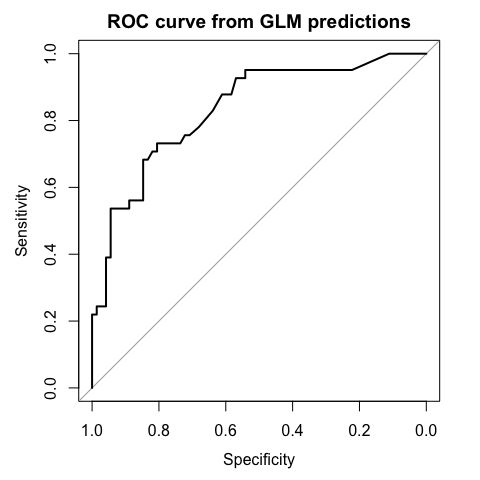

```r
# Fit a logistic regression model
model <- glm(outcome ~ s100b + wfns, data = aSAH, family = binomial)

# Get predicted probabilities
predictions <- predict(model, type = "response")

# Create ROC curve with the predictions
roc_glm <- roc(aSAH$outcome, predictions)

# Plot and compute AUC
plot(roc_glm, main = "ROC curve from GLM predictions")
```

```r
auc(roc_glm)
```

```
#> Area under the curve: 0.8337
```

## How do I remove empty space on the sides of my ROC plot?

Extra empty space can sometimes appear on either side of the x-axis in your ROC plots. This typically happens when the plotting device or window isn’t square. By default, pROC ensures the plot is square (with `asp = 1`) so that both sensitivity and specificity are on the same scale, which is important for visual interpretation.

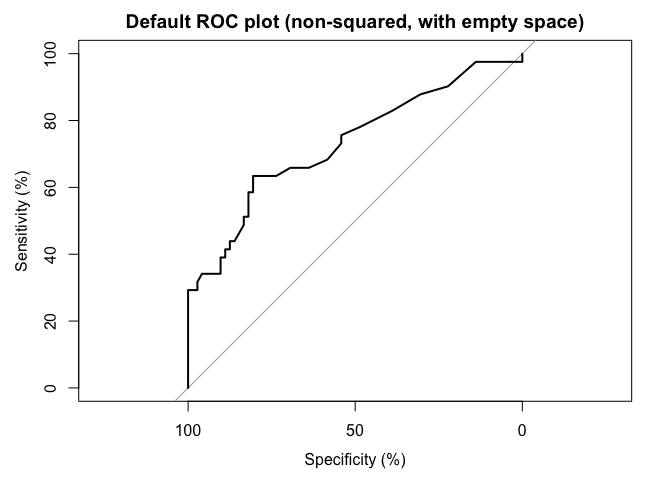

```r
rocobj <- roc(aSAH$outcome, aSAH$s100b, percent = TRUE)
plot(rocobj, main = "Default ROC plot (non-squared, with empty space)")
```

### Solution 1: Make the plotting region square

Use `par(pty = "s")` to make the plotting region square, which will automatically remove the extra space:

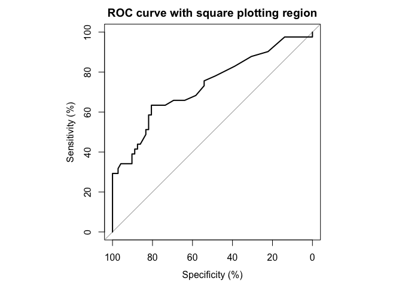

```r
par(pty = "s")
rocobj <- roc(aSAH$outcome, aSAH$s100b, percent = TRUE)
plot(rocobj, main = "ROC curve with square plotting region")
```

```r
par(pty = "m")  # Reset to default
```

### Solution 2: Adjust margins for square device

If you’re saving to a file, make sure the device is square and adjust margins so that top + bottom == left + right:

```r
# For file output
png("roc.png", width = 480, height = 480)
par(mar = c(4, 4, 4, 4) + 0.1)
plot(roc(aSAH$outcome, aSAH$s100b, percent = TRUE))
dev.off()
```

### Solution 3: Allow free aspect ratio (not recommended)

You can use `asp = NA` to allow a free (unconstrained) aspect ratio, but this will distort the axis and make visual interpretation of the ROC curve difficult. It’s better to keep the plot square for proper visual comparison.

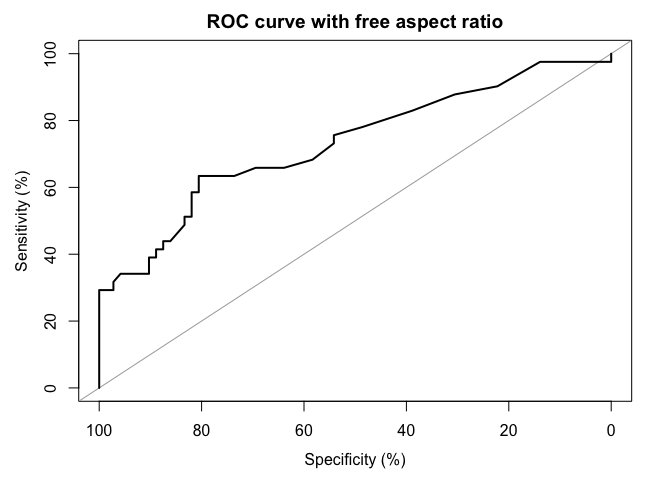

```r
rocobj <- roc(aSAH$outcome, aSAH$s100b, percent = TRUE)
plot(rocobj, main = "ROC curve with free aspect ratio", asp = NA)
```

**Note:** Having a squared ROC curve is important for visual interpretation, as it allows you to compare distances to the diagonal accurately. The default `asp = 1` ensures both axes have the same scale.

## When I resample or randomize my dataset I get an biased AUC > 0.5. How come?

This is because pROC tries to auto-detect the direction of the decision due to the default value of `direction="auto"`. The decision is based on the median of the groups instead of the AUC directly, so you the effect may not be 1:1, but you should expect to obtain AUC > 0.5 on average.

Whenever you are resampling with pROC you need to explicitly pass an explicit value to `direction`, either `direction="<"` or `direction=">"`. I also recommend taking a minute to set the `levels` (value of the `response` for controls and cases, respectively) argument explicitly too.

A future version of pROC will be more verbose and print a message when auto-detecting the direction.

## Can I test if a single ROC curve is significantly different from 0.5?

This is equivalent to asking whether the median values of cases and controls are significantly different. Therefore you can easily perform a [Wilcoxon Rank Sum Test](https://www.rdocumentation.org/packages/stats/topics/wilcox.test).

## My dataset is huge. Can I use pROC?

A large effort has been made to render pROC more and more efficient with large ROC curves. An algorithm with complexity of O(n) has been rolled out with pROC 1.6 and improved over time. Improvements to the DeLong test and the `coords` functions have been implemented too.

If you feel that a function is abnormally slow, especially in comparison to other packages, feel free to [open a bug report](https://github.com/xrobin/pROC/issues/new?template=Bug_report.md).

## Can I compute the confidence interval of the best threshold of the curve (not its SE/SP)?

Yes you can since pROC 1.6 and its `ci.coords` function. For instance:

```r
ci.coords(aSAH$outcome, aSAH$s100b, x="best", input = "threshold",
          ret="threshold")
# 95% CI (2000 stratified bootstrap replicates):
#            2.5%   50%  97.5%
# threshold 0.115 0.205 0.4854
```

There is 95% chance that the optimal threshold lies between 0.115 and 0.4854.

## The functions are giving me weird error messages I don’t understand

Several packages on CRAN provide alternative `roc` or `auc` functions. These packages can interfere with pROC, especially if they are loaded later in the session (and hence appear earlier in the search path).

For instance, here are a few messages you may see if you have the `AUC` package loaded:

```r
roc(outcome ~ ndka, data = aSAH)
# Not enough distinct predictions to compute area under the ROC curve.
#
# Error in roc(outcome ~ ndka, data = aSAH) : unused argument (data = aSAH)
```

If that happens, you should unload the package by typing `detach("package:AUC")`. To find out where the function is coming from, simply type its name on the R prompt:

```r
roc
```

In addition, you may have defined a `roc` function yourself. In this case, `rm(roc)` will solve the problem.

Alternatively you can refer to the pROC version of the function specifically through their namespace:

```r
pROC::auc(pROC::roc(aSAH$outcome, aSAH$ndka))
```

Here is a list of packages providing `roc`, `auc` and `ci` functions which will hide pROC’s functions if the package is loaded after pROC:

| Package | roc | auc | ci |
| --- | --- | --- | --- |
| analogue | [Generic](http://finzi.psych.upenn.edu/R/library/analogue/html/roc.html) |  |  |
| asbio |  | [Not Generic](http://finzi.psych.upenn.edu/R/library/asbio/html/auc.html) |  |
| AUC | [Not Generic](http://finzi.psych.upenn.edu/R/library/AUC/html/roc.html) | [Not Generic](http://finzi.psych.upenn.edu/R/library/AUC/html/auc.html) |  |
| aucm | [NA](http://finzi.psych.upenn.edu/R/library/aucm/html/roc.html) | [NA](http://finzi.psych.upenn.edu/R/library/aucm/html/auc.html) |  |
| cutpointr | [Not Generic](http://finzi.psych.upenn.edu/R/library/cutpointr/html/roc.html) |  |  |
| distillery |  |  | [Generic](http://finzi.psych.upenn.edu/R/library/distillery/html/ci.html) |
| enrichvs |  | [Not Generic](http://finzi.psych.upenn.edu/R/library/enrichvs/html/auc.html) |  |
| epiDisplay | [NA](http://finzi.psych.upenn.edu/R/library/epiDisplay/html/roc.html) |  | [Generic](http://finzi.psych.upenn.edu/R/library/epiDisplay/html/ci.html) |
| esvis |  | [Not Generic](http://finzi.psych.upenn.edu/R/library/esvis/html/auc.html) |  |
| FFTrees |  | [Not Generic](http://finzi.psych.upenn.edu/R/library/FFTrees/html/auc.html) |  |
| flux |  | [Not Generic](http://finzi.psych.upenn.edu/R/library/flux/html/auc.html) |  |
| fmsb | [Not Generic](http://finzi.psych.upenn.edu/R/library/fmsb/html/roc.html) |  |  |
| gmodels |  |  | [Generic](http://finzi.psych.upenn.edu/R/library/gmodels/html/ci.html) |
| grpreg |  | [NA](http://finzi.psych.upenn.edu/R/library/grpreg/html/auc.html) |  |
| hutils |  | [Not Generic](http://finzi.psych.upenn.edu/R/library/hutils/html/auc.html) |  |
| kulife |  | [Not Generic](http://finzi.psych.upenn.edu/R/library/kulife/html/auc.html) |  |
| longROC | [Not Generic](http://finzi.psych.upenn.edu/R/library/longROC/html/roc.html) | [Not Generic](http://finzi.psych.upenn.edu/R/library/longROC/html/auc.html) |  |
| MAMSE | [Not Generic](http://finzi.psych.upenn.edu/R/library/MAMSE/html/roc.html) |  |  |
| MESS |  | [Not Generic](http://finzi.psych.upenn.edu/R/library/MESS/html/auc.html) |  |
| Metrics |  | [Not Generic](http://finzi.psych.upenn.edu/R/library/Metrics/html/auc.html) |  |
| MXM |  | [Not Generic](http://finzi.psych.upenn.edu/R/library/MXM/html/auc.html) |  |
| ncvreg |  | [NA](http://finzi.psych.upenn.edu/R/library/ncvreg/html/auc.html) |  |
| NEArender | [Not Generic](http://finzi.psych.upenn.edu/R/library/NEArender/html/roc.html) |  |  |
| PK |  | [Not Generic](http://finzi.psych.upenn.edu/R/library/PK/html/auc.html) |  |
| precrec |  | [Generic](http://finzi.psych.upenn.edu/R/library/precrec/html/auc.html) |  |
| PresenceAbsence |  | [Not Generic](http://finzi.psych.upenn.edu/R/library/PresenceAbsence/html/auc.html) |  |
| radiant.model |  | [Not Generic](http://finzi.psych.upenn.edu/R/library/radiant.model/html/auc.html) |  |
| RMediation |  |  | [Not Generic](http://finzi.psych.upenn.edu/R/library/RMediation/html/ci.html) |
| sdm | [Generic](http://finzi.psych.upenn.edu/R/library/sdm/html/roc.html) |  |  |
| SDMTools |  | [Not Generic](http://finzi.psych.upenn.edu/R/library/SDMTools/html/auc.html) |  |
| spatstat |  | [Generic](http://finzi.psych.upenn.edu/R/library/spatstat/html/auc.html) |  |
| StatMeasures |  | [Not Generic](http://finzi.psych.upenn.edu/R/library/StatMeasures/html/auc.html) |  |
| survMisc |  |  | [Generic](http://finzi.psych.upenn.edu/R/library/survMisc/html/ci.html) |

To get an updated list, run `inst/extra/sos_clashes.R`. It may be needed to start R with `export R_MAX_NUM_DLLS=1000` to be able to run the script.